# Veri Seti

Veri setindeki düşük varyanslı değişken sayısı : 0

(#tab:deneme) Sayısal Değişkenlerin Tanımlayıcı İstatistikleri

|  | Overall |
| --- | --- |
| Age,years (mean $\pm$ SD) | 58 $\pm$ 10.8 |
| BMI, kg/m$^2$ (mean $\pm$ SD) | 24.8 $\pm$ 3.4 |
| Duration, months (mean $\pm$ SD) | 8.3 $\pm$ 9.6 |
| NRS (mean $\pm$ SD) | 4.4 $\pm$ 1.8 |
| CSA, mm$^2$ (mean $\pm$ SD) | 15.2 $\pm$ 4.3 |
| PB, mm (mean $\pm$ SD) | 2.5 $\pm$ 1.8 |

(#tab:descrip) Değişkenlerin Bağımlı Değişkene Göre Tanımlayıcı İstatistikleri (P-Value Değerleri Tek Yönlü Varyans Analiz Testi ile Elde Edilmiştir.)

|  | Mild | Moderate | Severe | P Value |
| --- | --- | --- | --- | --- |
| Age,years (mean $\pm$ SD) | 57.3 $\pm$ 10.6 | 59.2 $\pm$ 10.8 | 57.8 $\pm$ 11.2 | 0.069 |
| BMI, kg/m$^2$ (mean $\pm$ SD) | 24.2 $\pm$ 3.4 | 24.7 $\pm$ 3 | 25.8 $\pm$ 3.7 | 0 |
| Duration, months (mean $\pm$ SD) | 4.3 $\pm$ 5 | 8.5 $\pm$ 8.2 | 15.9 $\pm$ 12.8 | 0 |
| NRS (mean $\pm$ SD) | 3.3 $\pm$ 1.3 | 4.9 $\pm$ 1.5 | 6.1 $\pm$ 1.5 | 0 |
| CSA, mm$^2$ (mean $\pm$ SD) | 13.2 $\pm$ 3 | 15.4 $\pm$ 3.2 | 18.9 $\pm$ 5 | 0 |
| PB, mm (mean $\pm$ SD) | 2.1 $\pm$ 0.8 | 2.6 $\pm$ 2.4 | 3.1 $\pm$ 2.3 | 0 |

(#tab:catvar) Katagorik Değişkenlerin Bağımlı Değişkence Frekans Dağılımı (P-Value Değerleri Ki-Kare Bağımsızlık Testi ile Elde Edilmiştir.)

|  | Mild | Moderate | Severe | P value |
| --- | --- | --- | --- | --- |
| Eller, n (%) | 507 (48.9) | 276 (26.6) | 254 (24.5) | - |
| Cinsiyet (Kadın), n (%) | 308 (60.7) | 153 (55.4) | 171 (67.3) | 0.02 |
| Sağ El Kasılması, n (%) | 243 (47.9) | 149 (54) | 119 (46.9) | 0.181 |
| Diyabet, n (%) | 47 (9.3) | 45 (16.3) | 54 (21.3) | 0 |
| Gece Ağrıları, n (%) | 102 (20.1) | 142 (51.4) | 212 (83.5) | 0 |
| Avuç İçi Zayıflık ve/veya Körelme, n (%) | 1 (0.2) | 24 (8.7) | 169 (66.5) | 0 |

## Çok Sınıflı(Multiclass) Sınıflama Problemi

### K-En Yakın Komşuluk Modeli

Bu bölümde veri setimiz üzerinde K - En yakın komşuluk modelini kullanacak ve çıktılarını değerlendireceğiz.

#### Hiper Parametre Seçimi

Daha önce belirlediğimiz parametre uzayını ve Scikit-Learn kütüphanesinde bulunan GridSearchCV algoritması ile en uygun doğruluk oranını yakalayana kadar çalışması sağlandı.

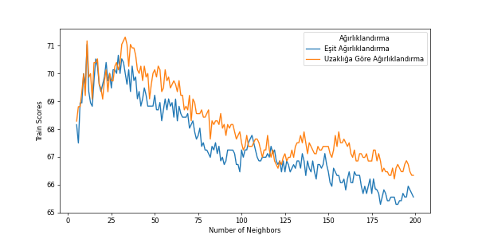

Model Train Scores

```
## En İyi Parametreler:{'algorithm':'auto','n_neighbors':33,'weights':'distance'}
```

#### En İyi Parametreli Model

GridSearchCV algoritması ile bulduğumuz parametrelerle kurulan modelimizin sınıflandırma metrikleri.

```
##               precision    recall  f1-score   support
##
##         Mild       0.76      0.92      0.83       137
##     Moderate       0.51      0.42      0.46        65
##       Severe       0.89      0.68      0.77        72
##
##     accuracy                           0.74       274
##    macro avg       0.72      0.67      0.69       274
## weighted avg       0.73      0.74      0.73       274
```

```
## Balanced Accuracy Score : 0.6718827333790838
```

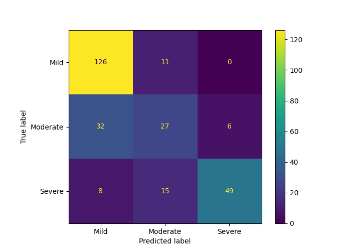

K-En Yakın Komşuluk Modeli Karmaşıklık Matrisi

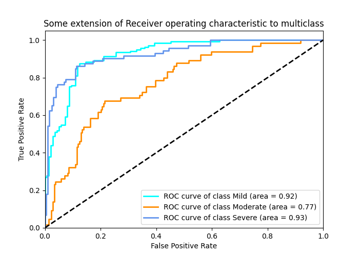

K-En Yakın Komşuluk Modeli ROC Eğrisi ve AUC Değeri

### Rassal Ormanlar Modeli

Bu bölümde veri setimiz üzerinde Rassal Ormanlar modelini kullanacak ve çıktılarını değerlendireceğiz.

#### Hiper Parametre Seçimi

Daha önce belirlediğimiz parametre uzayını ve Scikit-Learn kütüphanesinde bulunan GridSearchCV algoritması ile en uygun doğruluk oranını yakalayana kadar çalışması sağlandı.

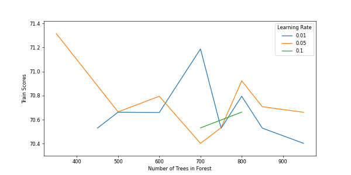

Model Train Scores

```
## En İyi Parametreler:{'ccp_alpha':0.05,'criterion':'gini','max_features':'auto',
## 'max_samples':10,'n_estimators':350}
```

#### En İyi Parametreli Model

GridSearchCV algoritması ile bulduğumuz parametrelerle kurulan modelimizin sınıflandırma metrikleri.

```
##               precision    recall  f1-score   support
##
##         Mild       0.73      0.99      0.84       137
##     Moderate       0.58      0.34      0.43        65
##       Severe       0.94      0.68      0.79        72
##
##     accuracy                           0.75       274
##    macro avg       0.75      0.67      0.69       274
## weighted avg       0.75      0.75      0.73       274
```

```
## Balanced Accuracy Score : 0.6681395179570361
```

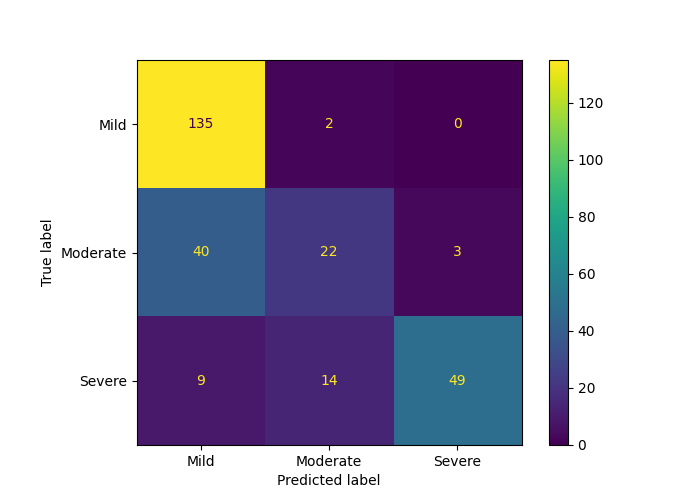

Rassal Ormanlar Modeli Karmaşıklık Matrisi

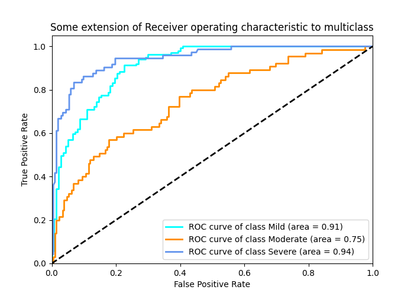

Rassal Ormanlar Modeli ROC Eğrisi ve AUC Değeri

### eXtreme Gradient Boosting (Xgboost)

Bu bölümde veri setimiz üzerinde XGBoost modelini kullanacak ve çıktılarını değerlendireceğiz.

#### Hiper Parametre Seçimi

Daha önce belirlediğimiz parametre uzayını ve Scikit-Learn kütüphanesinde bulunan GridSearchCV algoritması ile en uygun doğruluk oranını yakalayana kadar çalışması sağlandı.

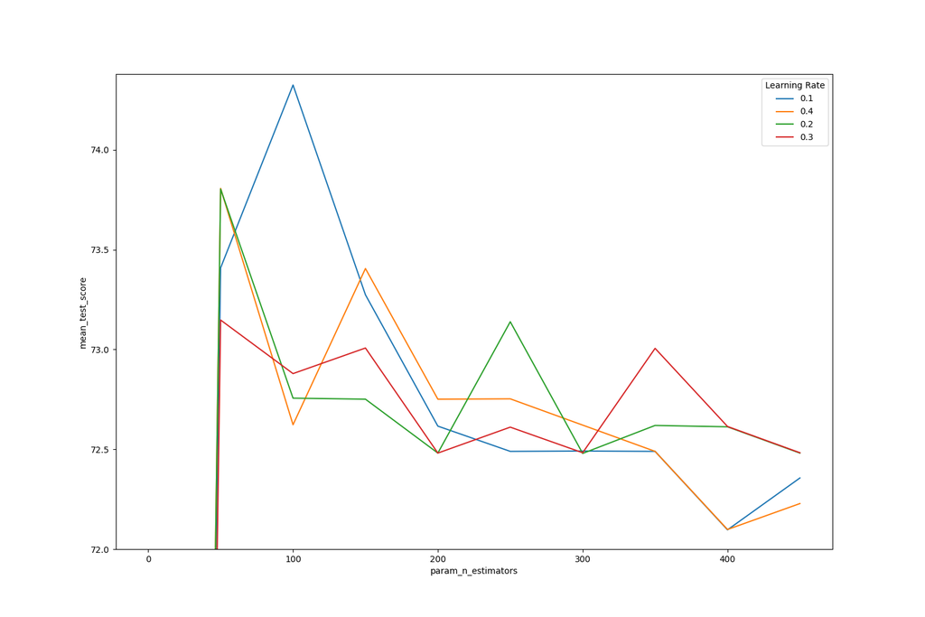

Model Train Scores

```
## En İyi Parametreler:{'booster':'gbtree2,'eta':0.1,'max_depth':3,'min_child_weight':
## 10,'n_estimators':100,'objective':'multi:softprob','sumsample':0.5}
```

GridSearchCV algoritması ile bulduğumuz parametrelerle kurulan modelimizin sınıflandırma metrikleri.

```
##               precision    recall  f1-score   support
##
##         Mild       0.80      0.89      0.84       137
##     Moderate       0.60      0.57      0.58        65
##       Severe       0.90      0.74      0.81        72
##
##     accuracy                           0.77       274
##    macro avg       0.76      0.73      0.74       274
## weighted avg       0.78      0.77      0.77       274
```

```
## Balanced Accuracy Score : 0.7319509430823299
```

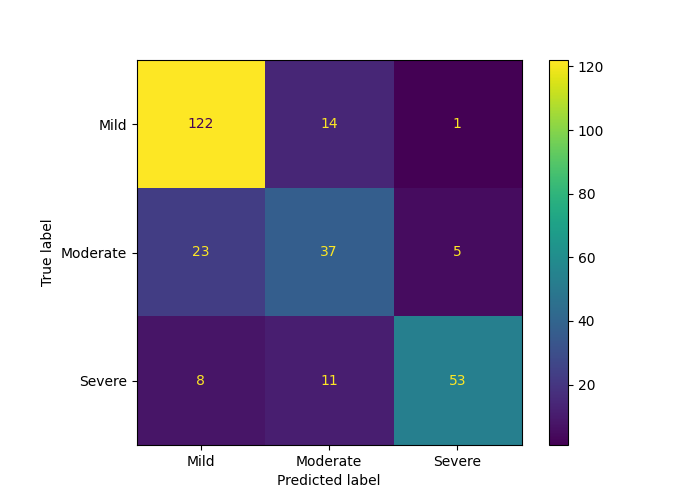

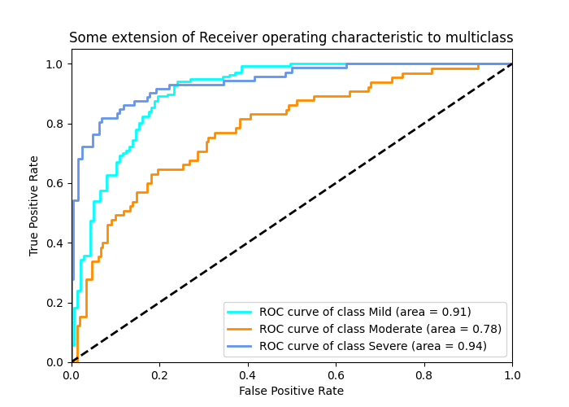

## İki Sınıflı Sınıflama

Bu bölümde orijinal hali 3 sınıftan oluşan veri setimizdeki görece az gözleme sahip olan 2 sınıfı birleştirip, 2 sınıflı probleme çözüm arayacağız.

### K-En Yakın Komşuluk Modeli

Bu bölümde veri setimiz üzerinde K - En yakın komşuluk modelini kullanacak ve çıktılarını değerlendireceğiz.

#### Hiper Parametre Seçimi

Scikit-Learn kütüphanesinde bulunan GridSearchCV algoritmasın en uygun doğruluk oranı bulunana kadar çalışması sağlandı.

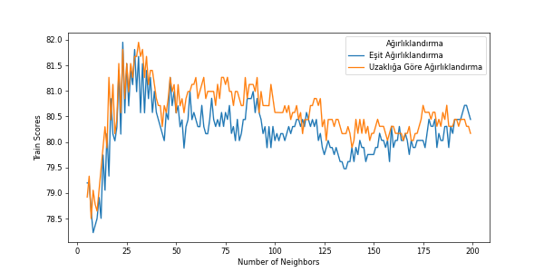

Model Train Scores

```
## En İyi Parametreler:{'algorithm':'auto','n_neighbors':23,'weights':'uniform'}
```

#### En İyi Parametreli Model

GridSearchCV algoritması ile bulduğumuz parametrelerle kurulan modelimizin sınıflandırma metrikleri.

```
##               precision    recall  f1-score   support
##
##            0       0.90      0.97      0.94       153
##            1       0.95      0.46      0.62       159
##            2       0.00      0.00      0.00         0
##
##     accuracy                           0.71       312
##    macro avg       0.62      0.48      0.52       312
## weighted avg       0.93      0.71      0.77       312
##
##
```

```
## Balanced Accuracy Score : 0.7164878530028364
##
```

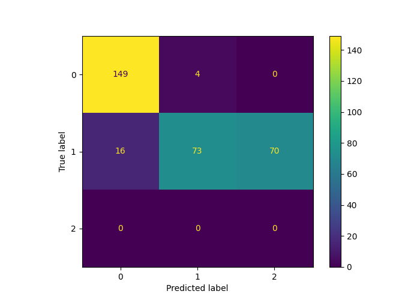

K-En Yakın Komşuluk Modeli Karmaşıklık Matrisi

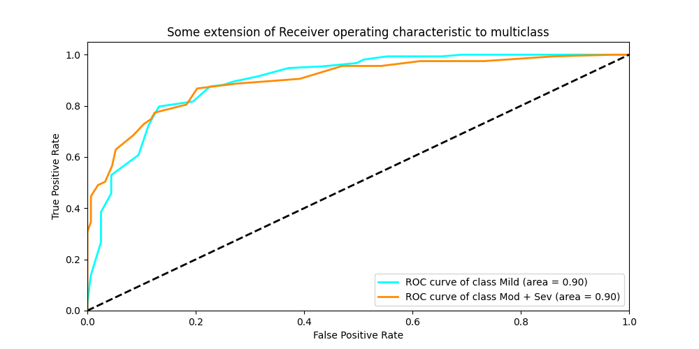

K-En Yakın Komşuluk Modeli ROC Eğrisi ve AUC Değeri